# 重賞レース予測レポート【レース終了】

作成日時: 2025/12/21 16:52:53

☞ [マニュアル(pdf)](https://ryutoro-galois.github.io/keiba-predictor/manual/manual.pdf)

☞ 過去5年の同一レース結果: [2024年](https://ryutoro-galois.github.io/keiba-predictor/report/PredResult_2024y_raceDate_20241214_20241215.html), [2023年](https://ryutoro-galois.github.io/keiba-predictor/report/PredResult_2023y_raceDate_20231216_20231217.html), [2022年](https://ryutoro-galois.github.io/keiba-predictor/report/PredResult_2022y_raceDate_20221217_20221218.html), [2021年](https://ryutoro-galois.github.io/keiba-predictor/report/PredResult_2021y_raceDate_20211218_20211219.html), [2020年](https://ryutoro-galois.github.io/keiba-predictor/report/PredResult_2020y_raceDate_20201219_20201220.html)

☞ 過去4週間の別レース結果: [1週前(12/13-14)](https://ryutoro-galois.github.io/keiba-predictor/report/PredResult_2025y_raceDate_20251213_20251214.html), [2週前(12/6-7)](https://ryutoro-galois.github.io/keiba-predictor/report/PredResult_2025y_raceDate_20251206_20251207.html), [3週前(11/29-30)](https://ryutoro-galois.github.io/keiba-predictor/report/PredResult_2025y_raceDate_20251129_20251130.html), [4週前(11/22-24)](https://ryutoro-galois.github.io/keiba-predictor/report/PredResult_2025y_raceDate_20251122_20251124.html)

☞ レース結果(csv): [12/20-21](https://ryutoro-galois.github.io/keiba-predictor/csv/race_result_20251220_20251221.csv)

## 【レース結果(1)】人気と着順の関係

### 【ターコイズステークス(2025/12/20(土))】

【ターコイズステークス(GⅢ)】  
2025/12/20(土), 06_中山, 芝右外1600m

[interactive chart not shown]

### 【朝日杯フューチュリティステークス(2025/12/21(日))】

【朝日杯フューチュリティステークス(GⅠ)】  
2025/12/21(日), 09_阪神, 芝右外1600m

[interactive chart not shown]

## 【レース結果(2)】コーナー通過順位

### 【ターコイズステークス(2025/12/20(土))】

【ターコイズステークス(GⅢ)】  
2025/12/20(土), 06_中山, 芝右外1600m

[interactive chart not shown]

### 【朝日杯フューチュリティステークス(2025/12/21(日))】

【朝日杯フューチュリティステークス(GⅠ)】  
2025/12/21(日), 09_阪神, 芝右外1600m

[interactive chart not shown]

## 0. 推し馬予測 (AI予測)

### 【ターコイズステークス(GⅢ) 2025/12/20(土)】

- 本命(◎): 1-3着内確率(勝負強さ)が1位の馬
- 対抗(◯): 1-3着内確率が2-N位(20%程度以上)の中で予測タイムが最も速い馬
- 3番手(▲): 1-3着内確率が2-N位(20%程度以上)のでダークホース確率が最も高い馬
- 穴: ダークホース確率が上位1-M位(40%程度以上)の中で1-3着内確率が最も高い馬

| 推し馬 | 枠番 | 馬番 | 人気 | オッズ | 馬名 | 騎手 | 調教師 | 予測タイム(sec) | 1_順位 | 1-3着内確率(%) | 2_順位 | ﾀﾞｰｸﾎｰｽ確率(%) | 3_順位 |
| --- | --- | --- | --- | --- | --- | --- | --- | --- | --- | --- | --- | --- | --- |
| 本命(◎) | 4 | 7 | 3 | 7.3 | ボンドガール | 津村明秀 | 手塚貴久 | 98.3 | 13 | 53.3 | 1 | 0.5 | 14 |
| 対抗(◯) | 5 | 9 | 4 | 8.6 | ビップデイジー | 西村淳也 | 松下武士 | 95.6 | 3 | 35.2 | 3 | 0.7 | 13 |
| 3番手(▲) | 3 | 5 | 10 | 15.9 | ソルトクィーン | 富田暁 | 武英智 | 96.2 | 6 | 21.3 | 6 | 34.1 | 4 |
| 穴 | 7 | 14 | 14 | 72.2 | フィールシンパシー | 菅原明良 | 小島茂之 | 97.4 | 9 | 8.4 | 11 | 46.0 | 2 |

### 【朝日杯フューチュリティステークス(GⅠ) 2025/12/21(日)】

- 本命(◎): 1-3着内確率(勝負強さ)が1位の馬
- 対抗(◯): 1-3着内確率が2-N位(20%程度以上)の中で予測タイムが最も速い馬
- 3番手(▲): 1-3着内確率が2-N位(20%程度以上)のでダークホース確率が最も高い馬
- 穴: ダークホース確率が上位1-M位(40%程度以上)の中で1-3着内確率が最も高い馬

| 推し馬 | 枠番 | 馬番 | 人気 | オッズ | 馬名 | 騎手 | 調教師 | 予測タイム(sec) | 1_順位 | 1-3着内確率(%) | 2_順位 | ﾀﾞｰｸﾎｰｽ確率(%) | 3_順位 |
| --- | --- | --- | --- | --- | --- | --- | --- | --- | --- | --- | --- | --- | --- |
| 本命(◎) | 8 | 13 | 3 | 4.4 | リアライズシリウス | 津村明秀 | 手塚貴久 | 99.1 | 3.0 | 34.5 | 1 | 6.3 | 8 |
| 対抗(◯) | 7 | 12 | 1 | 3.4 | アドマイヤクワッズ | 坂井瑠星 | 友道康夫 | 93.3 | 1.0 | 20.1 | 4 | 4.8 | 9 |
| 3番手(▲) | 6 | 9 | 7 | 27.3 | スペルーチェ | 三浦皇成 | 宮田敬介 | 99.6 | 10.0 | 20.0 | 5 | 4.7 | 10 |
| 穴 | 3 | 4 | 13 | 135.4 | コスモレッド | 藤岡佑介 | 北出成人 | 100.4 | 13.5 | 15.7 | 8 | 72.1 | 3 |

## 1. 予測チャート (タイム/勝負強さ)

### 【ターコイズステークス(GⅢ)】

2025/12/20(土), 06_中山, 芝右外1600m

[interactive chart not shown]

### 【朝日杯フューチュリティステークス(GⅠ)】

2025/12/21(日), 09_阪神, 芝右外1600m

[interactive chart not shown]

## 2. オッズモニタリング (毎時)

### 【ターコイズステークス】

[interactive chart not shown]

### 【朝日杯フューチュリティステークス】

[interactive chart not shown]

## 3. 出馬表

### 【ターコイズステークス 2025/12/20(土) 】

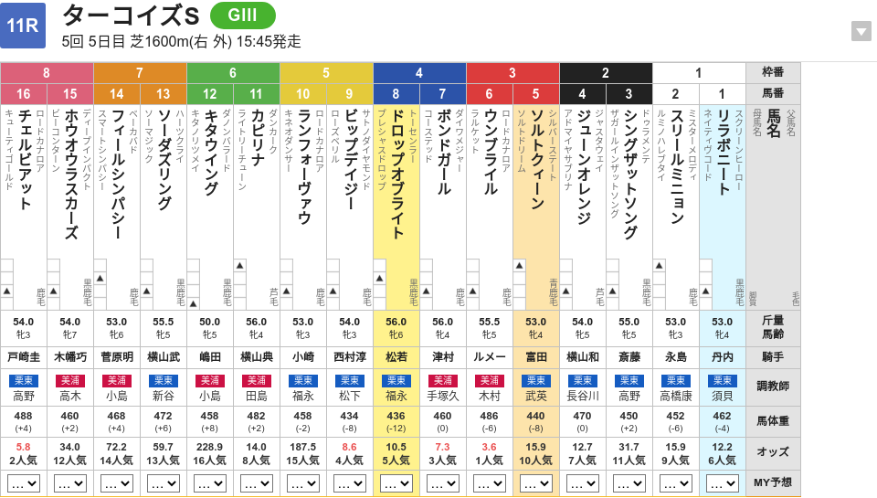

### 【朝日杯フューチュリティステークス 2025/12/21(日) 】

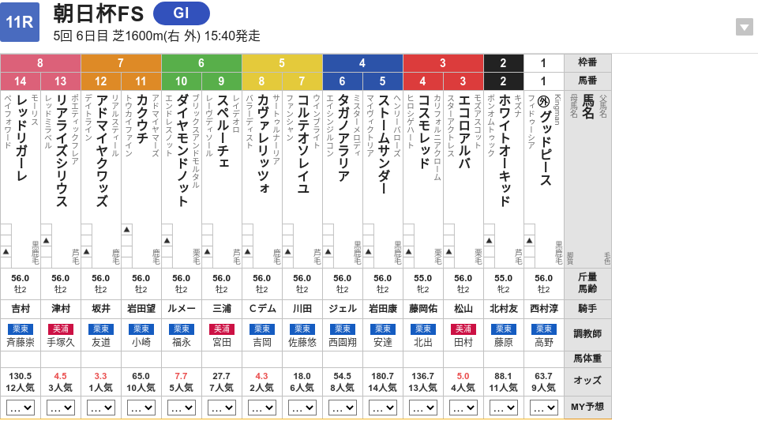

## 4. 単勝予測結果

### 【ターコイズステークス(GⅢ) 2025/12/20(土)】

| 枠番 | 馬番 | 人気 | オッズ | 馬名 | 騎手 | 調教師 | 予測タイム(sec) | 1_順位 | 1-3着内確率(%) | 2_順位 | ﾀﾞｰｸﾎｰｽ確率(%) | 3_順位 |
| --- | --- | --- | --- | --- | --- | --- | --- | --- | --- | --- | --- | --- |
| 1 | 1 | 6 | 12.2 | リラボニート | 丹内祐次 | 須貝尚介 | 96.2 | 7 | 27.9 | 4 | 1.5 | 10 |
| 1 | 2 | 9 | 15.9 | スリールミニョン | 永島まなみ | 高橋康之 | 94.3 | 2 | 19.7 | 7 | 34.1 | 3 |
| 2 | 3 | 11 | 31.7 | シングザットソング | 斎藤新 | 高野友和 | 100.8 | 16 | 5.8 | 14 | 52.0 | 1 |
| 2 | 4 | 7 | 12.7 | ジューンオレンジ | 横山和生 | 長谷川浩大 | 97.5 | 11 | 8.8 | 10 | 1.6 | 9 |
| 3 | 5 | 10 | 15.9 | ソルトクィーン | 富田暁 | 武英智 | 96.2 | 6 | 21.3 | 6 | 34.1 | 4 |
| 3 | 6 | 1 | 3.6 | ウンブライル | Ｃ．ルメール | 木村哲也 | 92.7 | 1 | 8.9 | 9 | 0.4 | 15 |
| 4 | 7 | 3 | 7.3 | ボンドガール | 津村明秀 | 手塚貴久 | 98.3 | 13 | 53.3 | 1 | 0.5 | 14 |
| 4 | 8 | 5 | 10.5 | ドロップオブライト | 松若風馬 | 福永祐一 | 97.5 | 10 | 9.3 | 8 | 1.0 | 12 |
| 5 | 9 | 4 | 8.6 | ビップデイジー | 西村淳也 | 松下武士 | 95.6 | 3 | 35.2 | 3 | 0.7 | 13 |
| 5 | 10 | 15 | 187.5 | ランフォーヴァウ | 小崎綾也 | 福永祐一 | 97.2 | 8 | 2.9 | 16 | 16.6 | 7 |

[output cut: 6 more lines]

### 【朝日杯フューチュリティステークス(GⅠ) 2025/12/21(日)】

| 枠番 | 馬番 | 人気 | オッズ | 馬名 | 騎手 | 調教師 | 予測タイム(sec) | 1_順位 | 1-3着内確率(%) | 2_順位 | ﾀﾞｰｸﾎｰｽ確率(%) | 3_順位 |
| --- | --- | --- | --- | --- | --- | --- | --- | --- | --- | --- | --- | --- |
| 1 | 1 | 9 | 63.5 | グッドピース | 西村淳也 | 高野友和 | 99.6 | 7.0 | 14.0 | 11 | 56.2 | 7 |
| 2 | 2 | 11 | 88.3 | ホワイトオーキッド | 北村友一 | 藤原英昭 | 100.4 | 13.5 | 14.3 | 10 | 67.4 | 4 |
| 3 | 3 | 4 | 5.0 | エコロアルバ | 松山弘平 | 田村康仁 | 99.1 | 3.0 | 30.3 | 2 | 4.5 | 12 |
| 3 | 4 | 13 | 135.4 | コスモレッド | 藤岡佑介 | 北出成人 | 100.4 | 13.5 | 15.7 | 8 | 72.1 | 3 |
| 4 | 5 | 14 | 179.6 | ストームサンダー | 岩田康誠 | 安達昭夫 | 99.6 | 7.0 | 14.8 | 9 | 73.1 | 2 |
| 4 | 6 | 8 | 53.6 | タガノアラリア | Ｆ．ジェルー | 西園翔 | 99.6 | 7.0 | 12.4 | 12 | 57.9 | 6 |
| 5 | 7 | 6 | 17.9 | コルテオソレイユ | 川田将雅 | 佐藤悠太 | 100.0 | 11.0 | 17.2 | 7 | 4.7 | 11 |
| 5 | 8 | 2 | 4.3 | カヴァレリッツォ | Ｃ．デムーロ | 吉岡辰弥 | 99.1 | 3.0 | 30.2 | 3 | 4.5 | 13 |
| 6 | 9 | 7 | 27.3 | スペルーチェ | 三浦皇成 | 宮田敬介 | 99.6 | 10.0 | 20.0 | 5 | 4.7 | 10 |
| 6 | 10 | 5 | 7.6 | ダイヤモンドノット | Ｃ．ルメール | 福永祐一 | 100.2 | 12.0 | 17.6 | 6 | 3.0 | 14 |

[output cut: 4 more lines]

## 5. 人気と着順の乖離率推移

### 【ターコイズステークス_2017y_2019y】

[interactive chart not shown]

### 【朝日杯フューチュリティステークス_2005y_2019y】

[interactive chart not shown]

### 【ターコイズステークス_2017y_2019y】

| No | 開催年 | 不整合率(%) | 頭数 | 人気別着順(1-3位) | 人気別着順(全体) |
| --- | --- | --- | --- | --- | --- |
| 3 | 2019 | 51.8 | 16頭 | 3-2-1 | 3\|2\|1\|12\|9\|11\|10\|15\|5\|13\|7\|14\|8\|16\|6\|4 |
| 2 | 2018 | 62.4 | 16頭 | 5-10-13 | 5\|10\|13\|4\|3\|6\|9\|1\|12\|8\|2\|11\|16\|7\|15\|14 |
| 1 | 2017 | 47.8 | 16頭 | 5-3-7 | 5\|3\|7\|1\|4\|6\|8\|2\|13\|11\|10\|14\|15\|9\|16\|12 |

### 【朝日杯フューチュリティステークス_2005y_2019y】

| No | 開催年 | 不整合率(%) | 頭数 | 人気別着順(1-3位) | 人気別着順(全体) |
| --- | --- | --- | --- | --- | --- |
| 15 | 2019 | 22.2 | 16頭 | 1-2-14 | 1\|2\|14\|9\|15\|10\|5\|6\|8\|3\|7\|16\|13\|12\|11\|4 |
| 14 | 2018 | 29.5 | 15頭 | 2-9-1 | 2\|9\|1\|3\|11\|7\|8\|14\|12\|5\|15\|6\|4\|13\|10 |
| 13 | 2017 | 17.7 | 16頭 | 1-3-2 | 1\|3\|2\|5\|4\|9\|10\|6\|7\|8\|13\|14\|12\|16\|11\|15 |
| 12 | 2016 | 39.9 | 18頭 | 6-7-12 | 6\|7\|12\|1\|8\|10\|3\|4\|9\|18\|17\|15\|2\|5\|14\|13\|11\|16 |
| 11 | 2015 | 27.8 | 16頭 | 2-1-11 | 2\|1\|11\|10\|3\|13\|8\|9\|5\|14\|4\|7\|15\|6\|16\|12 |
| 10 | 2014 | 26.3 | 18頭 | 1-14-3 | 1\|14\|3\|6\|9\|7\|2\|4\|10\|18\|5\|15\|13\|11\|12\|16\|17\|8 |
| 9 | 2013 | 38.3 | 16頭 | 4-6-5 | 4\|6\|5\|9\|1\|7\|2\|10\|12\|3\|8\|15\|14\|13\|11\|16 |
| 8 | 2012 | 35.3 | 16頭 | 7-1-3 | 7\|1\|3\|5\|6\|10\|4\|2\|8\|12\|13\|11\|9\|16\|15\|14 |
| 7 | 2011 | 32.2 | 16頭 | 1-4-8 | 1\|4\|8\|9\|3\|5\|2\|16\|6\|14\|7\|10\|12\|13\|15\|11 |
| 6 | 2010 | 41.9 | 16頭 | 5-4-2 | 5\|4\|2\|1\|3\|7\|16\|8\|10\|9\|6\|15\|12\|13\|11\|14 |

[output cut: 5 more lines]

## 6. 1-3番人気馬の着順分類予測

### 【ターコイズステークス】

| 分類 | 凡例 | 発生確率(%) | 当該レース | 当該レースランク | 直近1年間 |
| --- | --- | --- | --- | --- | --- |
| 1: 1番人気のみ (1_pop1) | 1 \| * \| * | 16.9 | 0.00 | 0.00 | 0.00 |
| 4: 1,2番人気のみ (4_pop12) | 1 \| 2 \| * | 16.3 | 0.00 | 0.00 | 0.33 |
| 8: 1,2,3番人気すべて着外 (8_darkhorse) | * \| * \| * | 13.9 | 1.11 | 1.11 | 0.00 |
| 5: 1,3番人気のみ (5_pop13) | 1 \| 3 \| * | 13.8 | 0.00 | 0.00 | 0.00 |
| 7: 1,2,3番人気すべて着内 (7_pop123) | 1 \| 2 \| 3 | 10.8 | 0.14 | 0.14 | 0.22 |
| 6: 2,3番人気のみ (6_pop23) | 2 \| 3 \| * | 9.8 | 0.00 | 0.00 | 0.00 |
| 2: 2番人気のみ (2_pop2) | 2 \| * \| * | 9.5 | 0.00 | 0.00 | 0.00 |
| 3: 3番人気のみ (3_pop3) | 3 \| * \| * | 9.2 | 0.74 | 0.74 | 0.00 |

### 【朝日杯フューチュリティステークス】

| 分類 | 凡例 | 発生確率(%) | 当該レース | 当該レースランク | 直近1年間 |
| --- | --- | --- | --- | --- | --- |
| 1: 1番人気のみ (1_pop1) | 1 \| * \| * | 16.9 | 3.38 | 3.38 | 0.00 |
| 4: 1,2番人気のみ (4_pop12) | 1 \| 2 \| * | 16.3 | 0.27 | 0.27 | 0.16 |
| 8: 1,2,3番人気すべて着外 (8_darkhorse) | * \| * \| * | 13.9 | 1.39 | 1.39 | 0.00 |
| 5: 1,3番人気のみ (5_pop13) | 1 \| 3 \| * | 13.8 | 1.38 | 1.38 | 0.00 |
| 7: 1,2,3番人気すべて着内 (7_pop123) | 1 \| 2 \| 3 | 10.8 | 2.16 | 2.16 | 0.00 |
| 6: 2,3番人気のみ (6_pop23) | 2 \| 3 \| * | 9.8 | 0.00 | 0.00 | 0.00 |
| 2: 2番人気のみ (2_pop2) | 2 \| * \| * | 9.5 | 1.90 | 1.90 | 0.00 |
| 3: 3番人気のみ (3_pop3) | 3 \| * \| * | 9.2 | 1.84 | 1.84 | 0.00 |

## 7. 3連複予測結果

### 【ターコイズステークス(GⅢ) 2025/12/20(土)】

| 分類 | 馬番 | 枠番 | 人気 | 平均予測タイム(sec) | 1-3着内確率(%) | ﾀﾞｰｸﾎｰｽ確率(%) | 馬名 | 騎手 | 調教師 |
| --- | --- | --- | --- | --- | --- | --- | --- | --- | --- |
| 6: 2,3番人気のみ (6_pop23) | 16-7-9 | 8-4-5 | 2-3-4 | 96.53 | 8.54 | 0.00 | チェルビアット \| ボンドガール \| ビップデイジー | 戸崎圭太 \| 津村明秀 \| 西村淳也 | 高野友和 \| 手塚貴久 \| 松下武士 |
| 6: 2,3番人気のみ (6_pop23) | 16-7-1 | 8-4-1 | 2-3-6 | 96.73 | 6.77 | 0.00 | チェルビアット \| ボンドガール \| リラボニート | 戸崎圭太 \| 津村明秀 \| 丹内祐次 | 高野友和 \| 手塚貴久 \| 須貝尚介 |
| 6: 2,3番人気のみ (6_pop23) | 16-7-11 | 8-4-6 | 2-3-8 | 96.70 | 5.38 | 0.00 | チェルビアット \| ボンドガール \| カピリナ | 戸崎圭太 \| 津村明秀 \| 横山典弘 | 高野友和 \| 手塚貴久 \| 田島俊明 |
| 3: 3番人気のみ (3_pop3) | 7-9-1 | 4-5-1 | 3-4-6 | 96.70 | 5.24 | 0.00 | ボンドガール \| ビップデイジー \| リラボニート | 津村明秀 \| 西村淳也 \| 丹内祐次 | 手塚貴久 \| 松下武士 \| 須貝尚介 |
| 6: 2,3番人気のみ (6_pop23) | 16-7-5 | 8-4-3 | 2-3-10 | 96.73 | 5.16 | 0.00 | チェルビアット \| ボンドガール \| ソルトクィーン | 戸崎圭太 \| 津村明秀 \| 富田暁 | 高野友和 \| 手塚貴久 \| 武英智 |
| 6: 2,3番人気のみ (6_pop23) | 16-7-2 | 8-4-1 | 2-3-9 | 96.10 | 4.76 | 0.00 | チェルビアット \| ボンドガール \| スリールミニョン | 戸崎圭太 \| 津村明秀 \| 永島まなみ | 高野友和 \| 手塚貴久 \| 高橋康之 |
| 2: 2番人気のみ (2_pop2) | 16-9-1 | 8-5-1 | 2-4-6 | 95.83 | 4.47 | 0.00 | チェルビアット \| ビップデイジー \| リラボニート | 戸崎圭太 \| 西村淳也 \| 丹内祐次 | 高野友和 \| 松下武士 \| 須貝尚介 |
| 3: 3番人気のみ (3_pop3) | 7-9-11 | 4-5-6 | 3-4-8 | 96.67 | 4.17 | 0.00 | ボンドガール \| ビップデイジー \| カピリナ | 津村明秀 \| 西村淳也 \| 横山典弘 | 手塚貴久 \| 松下武士 \| 田島俊明 |
| 3: 3番人気のみ (3_pop3) | 7-9-5 | 4-5-3 | 3-4-10 | 96.70 | 3.99 | 0.00 | ボンドガール \| ビップデイジー \| ソルトクィーン | 津村明秀 \| 西村淳也 \| 富田暁 | 手塚貴久 \| 松下武士 \| 武英智 |
| 3: 3番人気のみ (3_pop3) | 7-9-2 | 4-5-1 | 3-4-9 | 96.07 | 3.69 | 0.00 | ボンドガール \| ビップデイジー \| スリールミニョン | 津村明秀 \| 西村淳也 \| 永島まなみ | 手塚貴久 \| 松下武士 \| 高橋康之 |

[output cut: 550 more lines]

### 【朝日杯フューチュリティステークス(GⅠ) 2025/12/21(日)】

| 分類 | 馬番 | 枠番 | 人気 | 平均予測タイム(sec) | 1-3着内確率(%) | ﾀﾞｰｸﾎｰｽ確率(%) | 馬名 | 騎手 | 調教師 |
| --- | --- | --- | --- | --- | --- | --- | --- | --- | --- |
| 6: 2,3番人気のみ (6_pop23) | 8-13-3 | 5-8-3 | 2-3-4 | 99.10 | 3.16 | 0.01 | カヴァレリッツォ \| リアライズシリウス \| エコロアルバ | Ｃ．デムーロ \| 津村明秀 \| 松山弘平 | 吉岡辰弥 \| 手塚貴久 \| 田村康仁 |
| 5: 1,3番人気のみ (5_pop13) | 12-13-3 | 7-8-3 | 1-3-4 | 97.17 | 2.10 | 0.01 | アドマイヤクワッズ \| リアライズシリウス \| エコロアルバ | 坂井瑠星 \| 津村明秀 \| 松山弘平 | 友道康夫 \| 手塚貴久 \| 田村康仁 |
| 3: 3番人気のみ (3_pop3) | 13-3-9 | 8-3-6 | 3-4-7 | 99.27 | 2.09 | 0.01 | リアライズシリウス \| エコロアルバ \| スペルーチェ | 津村明秀 \| 松山弘平 \| 三浦皇成 | 手塚貴久 \| 田村康仁 \| 宮田敬介 |
| 7: 1,2,3番人気すべて着内 (7_pop123) | 12-8-13 | 7-5-8 | 1-2-3 | 97.17 | 2.09 | 0.01 | アドマイヤクワッズ \| カヴァレリッツォ \| リアライズシリウス | 坂井瑠星 \| Ｃ．デムーロ \| 津村明秀 | 友道康夫 \| 吉岡辰弥 \| 手塚貴久 |
| 6: 2,3番人気のみ (6_pop23) | 8-13-9 | 5-8-6 | 2-3-7 | 99.27 | 2.09 | 0.01 | カヴァレリッツォ \| リアライズシリウス \| スペルーチェ | Ｃ．デムーロ \| 津村明秀 \| 三浦皇成 | 吉岡辰弥 \| 手塚貴久 \| 宮田敬介 |
| 3: 3番人気のみ (3_pop3) | 13-3-10 | 8-3-6 | 3-4-5 | 99.47 | 1.84 | 0.01 | リアライズシリウス \| エコロアルバ \| ダイヤモンドノット | 津村明秀 \| 松山弘平 \| Ｃ．ルメール | 手塚貴久 \| 田村康仁 \| 福永祐一 |
| 4: 1,2番人気のみ (4_pop12) | 12-8-3 | 7-5-3 | 1-2-4 | 97.17 | 1.84 | 0.01 | アドマイヤクワッズ \| カヴァレリッツォ \| エコロアルバ | 坂井瑠星 \| Ｃ．デムーロ \| 松山弘平 | 友道康夫 \| 吉岡辰弥 \| 田村康仁 |
| 6: 2,3番人気のみ (6_pop23) | 8-13-10 | 5-8-6 | 2-3-5 | 99.47 | 1.84 | 0.01 | カヴァレリッツォ \| リアライズシリウス \| ダイヤモンドノット | Ｃ．デムーロ \| 津村明秀 \| Ｃ．ルメール | 吉岡辰弥 \| 手塚貴久 \| 福永祐一 |
| 2: 2番人気のみ (2_pop2) | 8-3-9 | 5-3-6 | 2-4-7 | 99.27 | 1.84 | 0.01 | カヴァレリッツォ \| エコロアルバ \| スペルーチェ | Ｃ．デムーロ \| 松山弘平 \| 三浦皇成 | 吉岡辰弥 \| 田村康仁 \| 宮田敬介 |
| 3: 3番人気のみ (3_pop3) | 13-3-7 | 8-3-5 | 3-4-6 | 99.40 | 1.80 | 0.01 | リアライズシリウス \| エコロアルバ \| コルテオソレイユ | 津村明秀 \| 松山弘平 \| 川田将雅 | 手塚貴久 \| 田村康仁 \| 佐藤悠太 |

[output cut: 354 more lines]

## 8. 直近の全レース情報

[output not shown]

[output cut: 11 more lines]